# The Fundamental Problem of Causal Inference

## Learning Goals:

1. Become familiar with the basic predictions of **conflict**, **contact**, and **constrict** theories (more on these in later weeks)
2. Recognize and differentiate **contextual** and **compositional (selection)** effects.
3. Explain how the **fundamental problem of causal inference** affects our ability to test for contextual effects

## Putnam review

- How would Putnam summarize the predictions of conflict and contact theories?
- According to Putnam, what effects does ethnic diversity have on social trust?

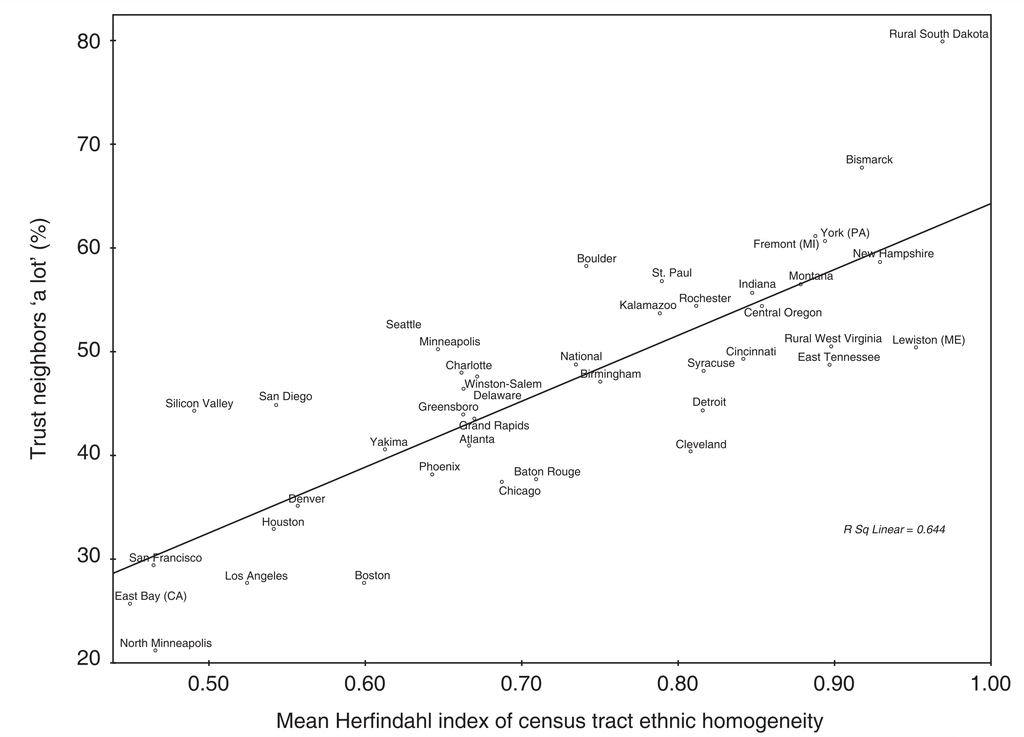

- What does the above figure show?
- From this figure, would you conclude that living next to people of a different race or ethnic background **causes** individuals to trust their neighbors less?

## Compositional vs. Contextual Effects

**A Thought Experiment**

Imagine two schools: a homogeneous school with all Dutch students and a diverse school with half Dutch students and half Bolivian students.

Dutch people are, on average, the tallest people in the world. Bolivians are, on average, the shortest.

If we are studying student height, we would most likely find that students in the diverse school are shorter, on average, than students in the homogeneous school.

Does diversity cause students to be short?

**Definitions**

- **Compositional effect**: there is something “sticky” about people (e.g. their personality or upbringing) that affects their attitudes and behavior. In other words, if we moved peoople to a new location, their attitudes and behavior would not change.
- **Contextual effect**: there is something about a location (context) that causes people to think and behave differently. If we moved peoople to a new location, their attitudes and behavior would start to resemble those of the people in that new location.

**Think-pair share**

Can you think of an example of two groups that differ on some characteristic, and where this difference is most likely the result of a compositional effect?

What about two groups where the difference most likely arises from a contextual effect?

**Group discusion**

Putnam shows that 80% of survey respondents from rural South Dakota say that they trust their neighbors “a lot”, compared to only 30% of survey respondents living in San Francisco.

What are some reasons for this difference?

Again, would you conclude that living next to people of a different race or ethnic background **causes** individuals to trust their neighbors less?

## Selection and the Fundamental Problem of Causal Inference

Conflict, Contact and Constrict theories all make predictions about how social *context* affects behavior and attitudes. In other words, these theories all hypothesize that exposure to (or interaction with) racial and ethnic “others” shapes individuals’ attitudes and behavior (we’ll talk about precisely how and why later in the course).

However, people also (self-)select into the contexts in which they live. As a result, differences in individuals’ attitudes and behavior may not (only) reflect the influence of their neighbors. Rather, researchers might also observe these differences because the individuals living in one area are themselves fundamentally different from the individuals living elsewhere.

In *observational studies* (i.e. where the researcher has no control over where individuals live), it is difficult to disentangle effects due to people (a compositional effect) from effects due to places (a contextual effect). This **fundamental problem of causal inference** undermines our ability to test contextual theories.

**Another example**

In criminology, the theory of “broken windows” suggests that crime increases when blighted areas appear to be abandoned by property owners and unsupervised by police. The causal question is whether one could reduce crime in such areas by picking up trash, removing graffiti, and repairing broken windows.

Suppose some researchers come up with the idea of comparing crime rates on streets with varying levels of property disrepair.

1. What do you think these researchers would find?
2. What do you think about the quality of this evidence?